# IODS course project

Olli Rantanen

# About the project and the first exercise

https://github.com/ollranta/IODS-project Things I will learn on this course will include: Data analysis, R, R-studio and Github. The course evaluation criteria is based on weekly exercises and the final project work. ***

# Olli Rantanen, 1.2.2017, Second exercise on R-Studio.

I started this exercises by “reading” the data of the learning2014 to the R-studio. Then I explored the statistical characteristics of the data. It was easier to do this exercise after the datacamp exercises because almost all of these were related to each other. This made it pretty straight forward to do and it did not require that much time.

1. Data was gathered from the students of the previous course (2014). The dataset has been cleared of those responders who had scored 0 points from the exam. We can explore these features by calling str() and dim() commands to our data. Our dataset has 166 rows and 7 columns. Str command tells us that the seven mentioned variables are gender, age, attitude, deep, stra, surf and points. Gender variable have only 2 options: woman and man. Of the respondents 56 were males and 110 were females. Age variable depends on the person’s age (mean 25.5) and points variable tells us how well they did score from the test (mean 22.7). The other variables are in a likert-scale which means they have values ranging from 1-5.
2. I made a graph which contains the relationship between points and attitude. As you can see from the picture, the points got from the grade correlate with the attitude towards statistics. So if you have a healthy attitude towards statistics, you also get a better grade. Also gender does not really affect the bigger picture.

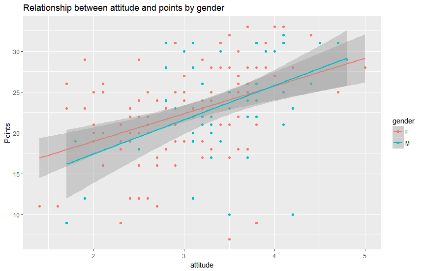

Here you can see the summary of the data variables.

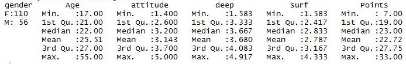

The next picture tells us how the different variables correlate with each other in a bigger picture. It is use d to quickly explore the relationship between multiple variables in a data frame. As you can see when for example attitude on the x-axis and y-axis collide the picture shows us how distributed attitude is between Man and Woman. Then on the left you can see distribution of data between other variables. On the right side you can see how they correlate with each other also with the gender.

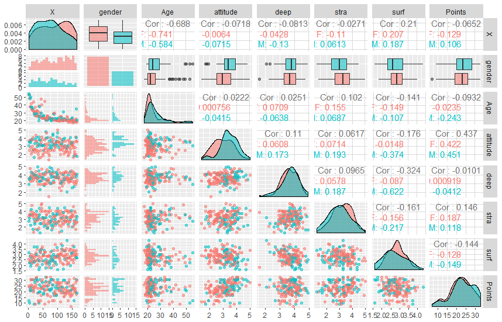

3. I chose as explanatory variables - attitude, stra and deep. As you can see on the summary photo, attitude seems to be the most significant factor affecting to the points.

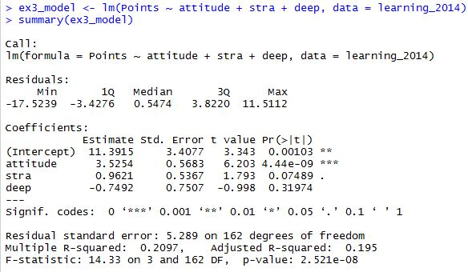

So the both factors still affect to the points scored from the test. Basically we can say that attitude is still the biggest factor explaining good points from the test.

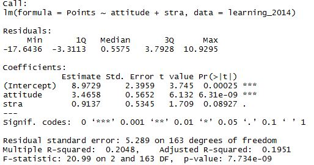

4. In both of these pictures you can see the R-squared value which means the coefficient of determination. The number tells us how good our model in the real world basically is. The r-squared value grows when you add more variables to the model. The adjusted r-squared is better because it takes into account the number of variables and it cannot be manipulated this way.

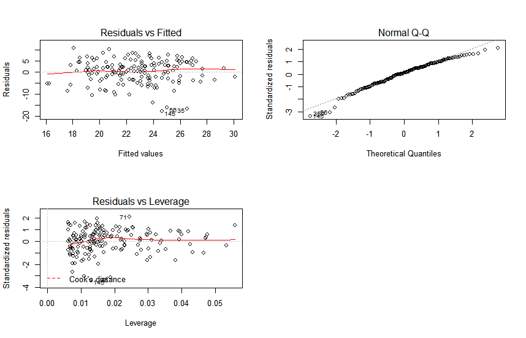

5. The picture above features all the diagnostic plots needed. Residuals vs fitted shows if the residuals have non-linear pattern. In our plot it does have a linear pattern which means our model works fine.

Normal Q-Q plot shows if the residuals are normally distributed. If the residuals are not fitted at all on the straight line they are not normally distributed. On our case that is not the question and the residuals are pretty much normally distributed.

On our last plot Residuals vs leverage we can interpret the extreme values. Tells us which points have the greatest influence on the regression. On this plot, focus is on the extreme cases and their influence to the regression analysis or the absence of this. When cases (dots) are outside of the red lide( cook’s distance) the cases are influential to the regression results.

To conclude the exercise, we can see that the exam result tends to be better with student use strategic learning and evern more if their attitude towards statistics is positive.

All my code is on the folder https://github.com/ollranta/IODS-project/blob/master/data < Unfortunately I was not able to add the code because some error message always came when I tried to upload it. I hope this does not ruin your day however and you are able to read it from the link.

# Third exercise with R-studio -Olli Rantanen, Logistic regression, 8.2.2017

At this chapter we will find new ways to handle data with logistic regression. I’m really looking forward to this and let’s see how I will succeed with these exercises.

Data got from https://archive.ics.uci.edu/ml/machine-learning-databases/00356/

### Reading the tables to R

```
mat <- read.csv("file:///Z:/Documents/tilastoi/Opendatasciense/chapter3/student-mat.csv", sep=";", header = T)
por <- read.csv("file:///Z:/Documents/tilastoi/Opendatasciense/chapter3/student-por.csv", sep = ";", header = T)
```

### Exploring the dimensions and structures of the dataset.

```
dim(mat)
structure(mat)
dim(por)
structure(por)
install.packages("dplyr")
library("dplyr")
install.packages("ggplot2")
library("ggplot2")
```

### Joining the data based on these variables

```
join_by <- c("school","sex","age","address","famsize","Pstatus","Medu","Fedu","Mjob","Fjob","reason","nursery","internet")
```

### Joining the two datasets

```
mat_por <- inner_join(mat, por, by = join_by, suffix = c(".math", ".por"))
structure(mat_por)
dim(mat_por)
```

### mat_por dataset has totally 382 observations and 53 variables. Now we can just copy the If statement (which is rather complicated to master on our own) from Datacamp

```
alco <- select(mat_por, one_of(join_by))
notjoined_columns <- colnames(mat)[!colnames(mat) %in% join_by]
print(notjoined_columns)
for(column_name in notjoined_columns) {
  two_columns <- select(mat_por, starts_with(column_name))
  first_column <- select(two_columns, 1)[[1]]
  if(is.numeric(first_column)) {
    alco[column_name] <- round(rowMeans(two_columns))
  } else {
    alco[column_name] <- first_column
  }
}
```

### Calculate the average consumption of alcohol in a week and also high_use

```
alco <- mutate(alco, alc_use= (Dalc + Walc)/2)
alco <- mutate(alco, high_use = (alc_use) > 2)
glimpse(alco)
```

### Observations: 382, Variables: 35

### now we just have to save the table and then we can move to the actual exercise

```
write.csv(alco, file = "file:///Z:/Documents/tilastoi/Opendatasciense/chapter3/alco.csv" , row.names = F)
alco_new <- read.csv("file:///Z:/Documents/tilastoi/Opendatasciense/chapter3/alco.csv")
alco_new
```

### Analysis Part 1-2

So for the final part of this exercise we will analyze the dataset which we just created about the student alcohol consumption. We should note that the data was edited for example we averaged the consumption to the whole week. Our dataset has 35 variables including information about personal attributes like: does he/she live in a rural part of the country, how much does he/she drink on a week and school success attributes like number of time failed on a test and grades. Totally we have 382 observations of this data. There are both numerical answers and true or false answers in the dataset.I will link my code for this part on my github because I think it would distract reading. https://github.com/ollranta/IODS-project/blob/master/code_C3

#### These are the column names in our data

```
> colnames(alco_new)
 [1] "school"      "sex"         "age"         "address"     "famsize"     "Pstatus"     "Medu"        "Fedu"
 [9] "Mjob"        "Fjob"        "reason"      "nursery"     "internet"    "guardian"    "traveltime"  "studytime"
[17] "failures"    "schoolsup"   "famsup"      "paid"        "activities"  "higher"      "romantic"    "famrel"
[25] "freetime"    "goout"       "Dalc"        "Walc"        "health"      "absences"    "G1"          "G2"
[33] "G3"          "alc_use"     "high_use"    "probability" "prediction"
```

### 3 - 4. Four variables which I chose for the analysis

Studytime, age, Famrel and Absences. The studytime is interesting because I would assume that people who study more tend to drink less than people who do not study that much. Age I chose because I think the age difference is quite big in this study 15-22 and I do not think that younger people drink as much as older people. Famrel-variable explains the quality of family relationships (1 very bad - 5 excellent) and I assume that people that have bad relationships with their families, tend to drink more. Absences I chose because I think it will be interesting to see if a lot of absences affect to the drinking. So let’s start by adding boxplot of these variables to the consumption of alcohol. The boxplots are read in a way that on X-axis is False statetment, which means that the student is not a high alcohol user. The True side on the other hand means that the student is a high consumer of alcohol. On the Y-axis is for example likert scale from 1-5. The genders are marked blue for boys and red for girls.

### I chose variables famrel, Age, studytime and absences and I will use boxplots to find how they affect each other

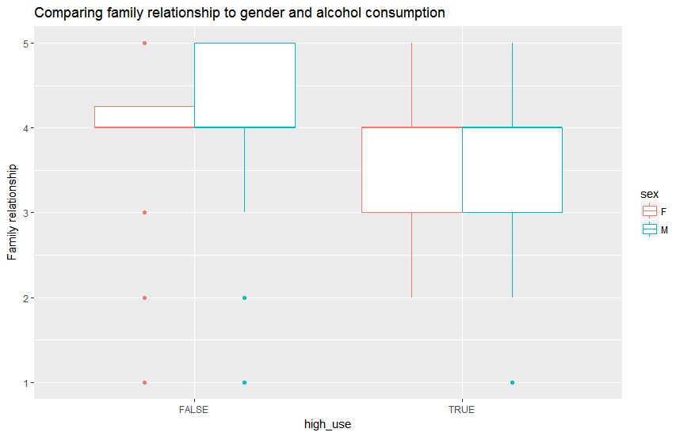

As we can see when the family relationship is better the consumption is lower and vice versa. This was our hypothesis also. Now let’s do the same thing to Age.

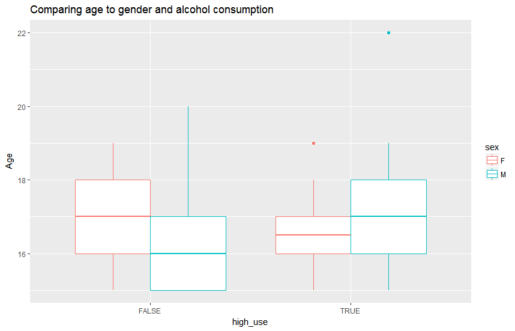

Interestingly it seems that younger woman tend to use alcohol more than older women, which is not on line with our hypothesis. On the other hand Men tend to consume more alcohol when they are older which is on line with the hypothesis. I must also address that the differences are not that high.

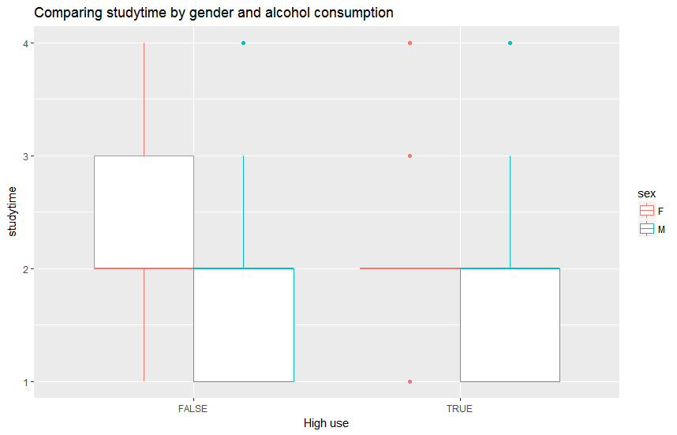

We can see that our hypothesis of the studytime only affect the women. Men do not study that much it seems. The hypothesis was therefore correct only on the women’s side.

Let’s see how the absences affect to drinking.

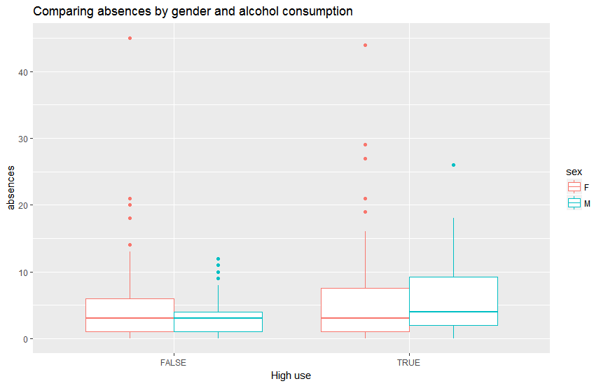

So it seems that the the more you are absent the more you consume alcohol. The difference is much higher with men but the difference can be seen also on the women side. The hypothesis was therefore correct.

### 5. Logistic regression

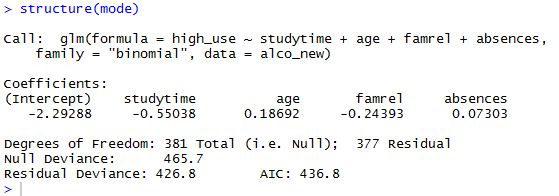

So this is what we got of our model with the cbind function, which interprets coefficients to odd ratios. Our widest confidence interval seems to be variable age (0.99 - 1.48) and the thinnest is absences (1.03 - 1.13). Intervals are read in a way for example that there is a 95 % probability that the odd ratio of absences is between the confidence interval (1.03 - 1.13). So the wider the interval, the more inaccurate is our model also. Odd ratios means the odds that an outcome will occur with the given exposure, compared to the odds of the outcome happening without the exposure. The higher the OR is, it is more likely that you consume alcohol and vice versa. This is according to our previous hypothesis and it seems that our model worked fine.

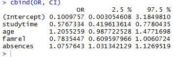

### 6. Predicting

Our model is made in a way it predicts the probability of using a lot of alcohol TRUE if it is higher than 0.5. If it falls under that it says it is FALSE. After that we can compare our own model and the prediction model.

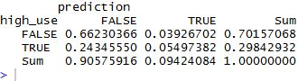

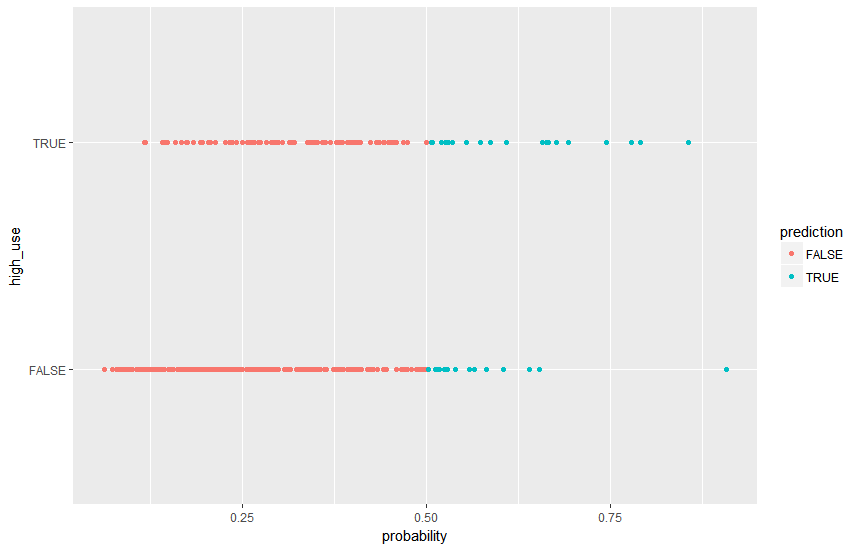

0.2827225 Is the mean prediction error of the predictive model. This means that 28.2 % of the model predictions are incorrect compared to real data.

### Bonus 7.

The 10-fold cross validation results for our model: 0.2879581

Datacamp-result [1] 0.2643979 So our model did worse than the datacamp model because it has a lower prediction error value than our model. I could not find such model which could beat the datacamp model.

### Conclusion

It seems our model and hypothesis were pretty good predicting the likelihood of high alcohol usage. Also the picked variables worked fine with this exercise. My personal hypothesis worked pretty well, considering 2/4 were correct and the last two were not totally wrong. The Datacamp error rate was lower than ours which is unfortunate, still I think I did a pretty good job with the prediction error of only 2.3 % higher than the datacamp. The exercise was quite long and time consuming. Luckily the Datacamp helped a lot making these models and I think I also learned a lot of new things about statistics

All my code for the second part can be found here https://github.com/ollranta/IODS-project/blob/master/code_C3

# Chapter 4, Clustering and classification, Olli Rantanen 17.02.2017

This time our exercise is about clustering and classification. Our data “Housing Values in Suburbs of Boston” has variables about crime, socioeconomical factors for example “lower status of the population” and many other kinds of information about the population on the area. The most important variable is crime (crim) which is described to represent the per capita crime rate by town. The data frame has 506 rows and 14 columns totally. Let’s bring our data and have a look of its structure

```
install.packages("MASS")
library(MASS)
data("Boston")
str(Boston)
dim(Boston)

# 'data.frame': 506 obs. of  14 variables:
 $ crim   : num  0.00632 0.02731 0.02729 0.03237 0.06905 ...
 $ zn     : num  18 0 0 0 0 0 12.5 12.5 12.5 12.5 ...
 $ indus  : num  2.31 7.07 7.07 2.18 2.18 2.18 7.87 7.87 7.87 7.87 ...
 $ chas   : int  0 0 0 0 0 0 0 0 0 0 ...
 $ nox    : num  0.538 0.469 0.469 0.458 0.458 0.458 0.524 0.524 0.524 0.524 ...
 $ rm     : num  6.58 6.42 7.18 7 7.15 ...
 $ age    : num  65.2 78.9 61.1 45.8 54.2 58.7 66.6 96.1 100 85.9 ...
 $ dis    : num  4.09 4.97 4.97 6.06 6.06 ...
 $ rad    : int  1 2 2 3 3 3 5 5 5 5 ...
 $ tax    : num  296 242 242 222 222 222 311 311 311 311 ...
 $ ptratio: num  15.3 17.8 17.8 18.7 18.7 18.7 15.2 15.2 15.2 15.2 ...
 $ black  : num  397 397 393 395 397 ...
 $ lstat  : num  4.98 9.14 4.03 2.94 5.33 ...
 $ medv   : num  24 21.6 34.7 33.4 36.2 28.7 22.9 27.1 16.5 18.9 ...

[1] 506  14
```

And let’s have a closer look of the variables of the data frame

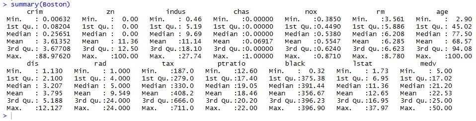

After that we can focus on making a graphical summary with correlation matrix

```
cor_matrix<-cor(Boston)

cor_matrix<-cor(Boston) %>% round(digits=2)

corrplot(cor_matrix, method="circle", type = "upper", cl.pos = "b", tl.pos = "d", tl.cex = 0.6)
```

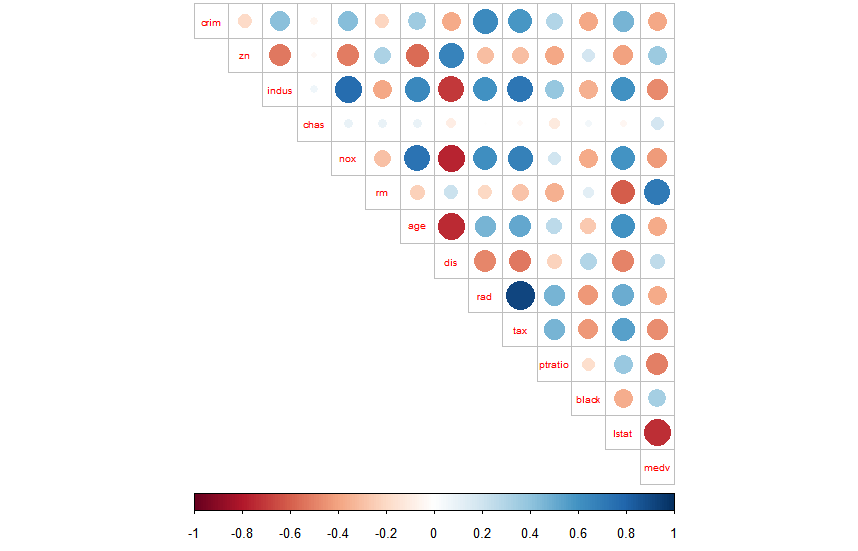

From this matrix you can see how the variables correlate negatively or positevely with each other. For example dis “weighted mean of distances to five Boston employment centres” correlates very negatively with age“proportin of owner-occupied units built prior to 1940”, nox" nitrogen oxides concentration (parts per 10 million)" and indus“proportion of non-retail business acres per town”. So the bigger and redder the circle the more negative the correlation. Positively correlated are the circles which are big and most blue. For example rad “accessibility to radial highways” and tax “full-value property-tax rate per$10,000” correlate the most within our dataset. This chart makes it very easy to make observations of the correlation between the variables.

```
> cor_matrix
         crim    zn indus  chas   nox    rm   age   dis   rad   tax ptratio black lstat  medv
crim     1.00 -0.20  0.41 -0.06  0.42 -0.22  0.35 -0.38  0.63  0.58    0.29 -0.39  0.46 -0.39
zn      -0.20  1.00 -0.53 -0.04 -0.52  0.31 -0.57  0.66 -0.31 -0.31   -0.39  0.18 -0.41  0.36
indus    0.41 -0.53  1.00  0.06  0.76 -0.39  0.64 -0.71  0.60  0.72    0.38 -0.36  0.60 -0.48
chas    -0.06 -0.04  0.06  1.00  0.09  0.09  0.09 -0.10 -0.01 -0.04   -0.12  0.05 -0.05  0.18
nox      0.42 -0.52  0.76  0.09  1.00 -0.30  0.73 -0.77  0.61  0.67    0.19 -0.38  0.59 -0.43
rm      -0.22  0.31 -0.39  0.09 -0.30  1.00 -0.24  0.21 -0.21 -0.29   -0.36  0.13 -0.61  0.70
age      0.35 -0.57  0.64  0.09  0.73 -0.24  1.00 -0.75  0.46  0.51    0.26 -0.27  0.60 -0.38
dis     -0.38  0.66 -0.71 -0.10 -0.77  0.21 -0.75  1.00 -0.49 -0.53   -0.23  0.29 -0.50  0.25
rad      0.63 -0.31  0.60 -0.01  0.61 -0.21  0.46 -0.49  1.00  0.91    0.46 -0.44  0.49 -0.38
tax      0.58 -0.31  0.72 -0.04  0.67 -0.29  0.51 -0.53  0.91  1.00    0.46 -0.44  0.54 -0.47
ptratio  0.29 -0.39  0.38 -0.12  0.19 -0.36  0.26 -0.23  0.46  0.46    1.00 -0.18  0.37 -0.51
black   -0.39  0.18 -0.36  0.05 -0.38  0.13 -0.27  0.29 -0.44 -0.44   -0.18  1.00 -0.37  0.33
lstat    0.46 -0.41  0.60 -0.05  0.59 -0.61  0.60 -0.50  0.49  0.54    0.37 -0.37  1.00 -0.74
medv    -0.39  0.36 -0.48  0.18 -0.43  0.70 -0.38  0.25 -0.38 -0.47   -0.51  0.33 -0.74  1.00
```

After that we can scale the variables to standardize the data set. If you compare this variable summary to the previous summary, you can see that the scales are very different on the first summary compared to the scaled one. For example on the first summary the minimum value of tax is “187” and maximum “711” compared to nox where minimum is “0.3850” and maximum is “0.8710”.

```
boston_scaled <- scale(Boston)
summary(boston_scaled)
class(boston_scaled)

      crim                 zn               indus              chas              nox                rm
 Min.   :-0.419367   Min.   :-0.48724   Min.   :-1.5563   Min.   :-0.2723   Min.   :-1.4644   Min.   :-3.8764
 1st Qu.:-0.410563   1st Qu.:-0.48724   1st Qu.:-0.8668   1st Qu.:-0.2723   1st Qu.:-0.9121   1st Qu.:-0.5681
 Median :-0.390280   Median :-0.48724   Median :-0.2109   Median :-0.2723   Median :-0.1441   Median :-0.1084
 Mean   : 0.000000   Mean   : 0.00000   Mean   : 0.0000   Mean   : 0.0000   Mean   : 0.0000   Mean   : 0.0000
 3rd Qu.: 0.007389   3rd Qu.: 0.04872   3rd Qu.: 1.0150   3rd Qu.:-0.2723   3rd Qu.: 0.5981   3rd Qu.: 0.4823
 Max.   : 9.924110   Max.   : 3.80047   Max.   : 2.4202   Max.   : 3.6648   Max.   : 2.7296   Max.   : 3.5515
      age               dis               rad               tax             ptratio            black
 Min.   :-2.3331   Min.   :-1.2658   Min.   :-0.9819   Min.   :-1.3127   Min.   :-2.7047   Min.   :-3.9033
 1st Qu.:-0.8366   1st Qu.:-0.8049   1st Qu.:-0.6373   1st Qu.:-0.7668   1st Qu.:-0.4876   1st Qu.: 0.2049
 Median : 0.3171   Median :-0.2790   Median :-0.5225   Median :-0.4642   Median : 0.2746   Median : 0.3808
 Mean   : 0.0000   Mean   : 0.0000   Mean   : 0.0000   Mean   : 0.0000   Mean   : 0.0000   Mean   : 0.0000
 3rd Qu.: 0.9059   3rd Qu.: 0.6617   3rd Qu.: 1.6596   3rd Qu.: 1.5294   3rd Qu.: 0.8058   3rd Qu.: 0.4332
 Max.   : 1.1164   Max.   : 3.9566   Max.   : 1.6596   Max.   : 1.7964   Max.   : 1.6372   Max.   : 0.4406
     lstat              medv
 Min.   :-1.5296   Min.   :-1.9063
 1st Qu.:-0.7986   1st Qu.:-0.5989
 Median :-0.1811   Median :-0.1449
 Mean   : 0.0000   Mean   : 0.0000
 3rd Qu.: 0.6024   3rd Qu.: 0.2683
 Max.   : 3.5453   Max.   : 2.9865
```

The next part is to convert the dataset as dataframe and it is very simple with boston_scaled <- as.data.frame(boston_scaled) command. Then we move the crim variable as our primary focus. This is done by making its values into categories.

```
Scaled crim

       V1
 Min.   :-0.419367
 1st Qu.:-0.410563
 Median :-0.390280
 Mean   : 0.000000
 3rd Qu.: 0.007389
 Max.   : 9.924110

bins <- quantile(scaled_crim)
bins
           0%          25%          50%          75%         100%
-0.419366929 -0.410563278 -0.390280295  0.007389247  9.924109610


Making it into the categories
scaled_crim <- scale(boston_scaled$crim)
summary(scaled_crim)

bins <- quantile(scaled_crim)
bins
table(crime)
crime <- cut(scaled_crim, breaks = bins, include.lowest = TRUE, label = c("low", "med_low", "med_high", "high"))

table(crime)
crime
     low  med_low med_high     high
     127      126      126      127
```

As you can see above the categories now have values ranging from low to high crime with each category having at least 126 values on their own.

We can now delete the original “crim” from the dataset and add the new “crime” to it. Then we can divide dataset to train and as test sets to make sure our model is working. It is always important to test how well the predictions fit to our model.

```
boston_scaled <- dplyr::select(boston_scaled, -crim)
boston_scaled <- data.frame(boston_scaled, crime)
n <- nrow(boston_scaled)

ind <- sample(n,  size = n * 0.8)
train <- boston_scaled[ind,]
test <- boston_scaled[-ind,]

correct_classes <- test$crime
test <- dplyr::select(test, -crime)
```

### Now we can fit the LDA on the train set.

Linear discriminant analysis finds the linear combination of the variables that separate the target variable classes. By this we can reduce dimensions of our data and cluster it. We will use the newly made crime rate as our target variable.

```
lda.fit <- lda(crime~. , data = train)
lda.fit
lda.arrows <- function(x, myscale = 1, arrow_heads = 0.1, color = "red", tex = 0.75, choices = c(1,2)){
  heads <- coef(x)
  arrows(x0 = 0, y0 = 0,
         x1 = myscale * heads[,choices[1]],
         y1 = myscale * heads[,choices[2]], col=color, length = arrow_heads)
  text(myscale * heads[,choices], labels = row.names(heads),
       cex = tex, col=color, pos=3)
}

classes <- as.numeric(train$crime)
plot(classes, dimen = 2, col = classes,  pch = classes)
lda.arrows(lda.fit, myscale = 1)
```

And here is the result

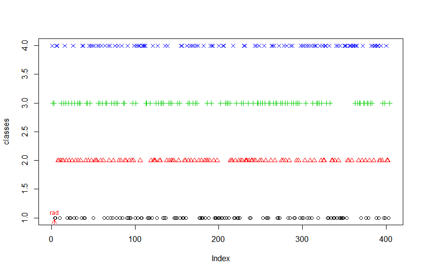

The arrow that came through is rad, which means that accessibility to radial highways would explain the crime rates according to our model. We can test this with cross tabulating the data.

```
lda.pred <- predict(lda.fit, newdata = test)

table(correct = correct_classes, predicted = lda.pred$class)

 predicted
correct    low med_low med_high high
  low       13       9        1    0
  med_low    5      16        2    0
  med_high   0      10       17    2
  high       0       0        0   27
```

Looks like the most accurate prediction was with “high crime” and the lowest was with “low crime”. This basically means that its easier for the model to predict high crime rates and harder to predict low crime rates.

### Distance measures and clustering

We use manhattan and euclidean distance measures for finding the similarity or dissimilarity of objects. As we can see below these distances vary in many ways between all the core statistics.

```
data("Boston")
boston_scaled1 <- scale(Boston)
summary(boston_scaled1)

dist_eu <- dist(boston_scaled1)
summary(dist_eu)

dist_man <- dist(boston_scaled1, method =  "manhattan")
summary(dist_man)

dist_eu <- dist(boston_scaled1)


> summary(dist_eu)
   Min. 1st Qu.  Median    Mean 3rd Qu.    Max.
 0.1343  3.4620  4.8240  4.9110  6.1860 14.4000


> summary(dist_man)
   Min. 1st Qu.  Median    Mean 3rd Qu.    Max.
 0.2662  8.4830 12.6100 13.5500 17.7600 48.8600
>
```

Now we can do the first clustering with calculated distances.

```
km <- kmeans(dist_eu, centers = 15)
km
# plot the Boston dataset with clusters
pairs(boston_scaled1, col = km$cluster)
```

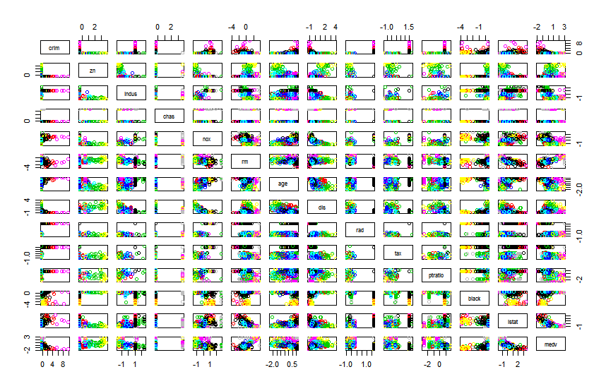

We also do the k-means clustering which does unsupervised clustering based on the similarity of the objects. To do the K-mean function, it need an argument on how many clusters it uses. We will find the optimal amount by doing WCSS. WCSS uses total of within cluster sum of squares behaves when the number of cluster changes. This means when we plot the number of clusters and total WCSS, we will see a dramatic drop somewhere on the plot. When the dramatic occurs, this is the number of clusters we shoulds use. As you can see below this number is two.

```
set.seed(123)
k_max <- 10

twcss <- sapply(1:k_max, function(k){kmeans(dist_eu, k)$tot.withinss})
plot(1:k_max, twcss, type='b')
```

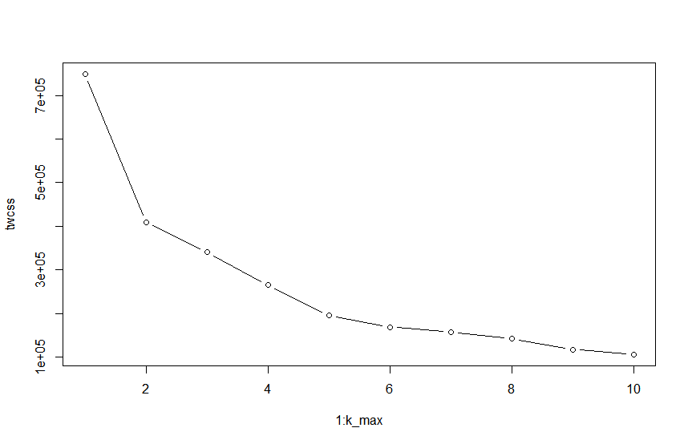

```
# k-means clustering
km <-kmeans(dist_eu, centers = 2)

# plot the Boston dataset with clusters
pairs(boston_scaled1, col = km$cluster)
```

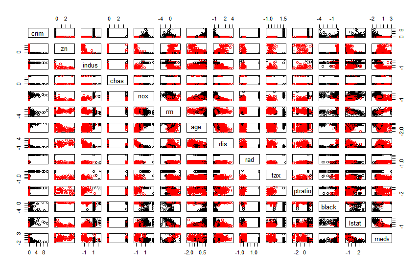

It might be a bit hard to interpret any results on this because of the size of the picture. However we can see the red spot and black spot mixing and being separate also in some cases. Like rad and tax with crime variable. Medv (median value of owner-occupied homes in $1000s) and age (proportion of owner-occupied units built prior to 1940) seem to be mixing a lot.

Let´s try the superbonus also cause why not

```
model_predictors <- dplyr::select(train, -crime)

dim(model_predictors)
dim(lda.fit$scaling)

matrix_product <- as.matrix(model_predictors) %*% lda.fit$scaling
matrix_product <- as.data.frame(matrix_product)

install.packages("plotly")
library(plotly)

plot_ly(surfacecolor = train$crime, x = matrix_product$LD1, y = matrix_product$LD2, z = matrix_product$LD3, type= 'scatter3d', mode='markers')
```

Unfortunately the error message saying “Webgl is not supported by your browser” keeps on coming and I was not able to download the wanted program for the school’s computer. I also tried changing the plot_ly funtion but nothing seemed to work.. Maybe 1 point for a good effort ;)

# Chapter 4 - data wrangling

This part is for the next week and it consists of data wrangling exercises which I will link to the Github also.

```
hd <- read.csv("http://s3.amazonaws.com/assets.datacamp.com/production/course_2218/datasets/human_development.csv", stringsAsFactors = F)
gii <- read.csv("http://s3.amazonaws.com/assets.datacamp.com/production/course_2218/datasets/gender_inequality.csv", stringsAsFactors = F, na.strings = "..")
```

Let’s explore the structure, dimensions and summaries of the data frames

```
dim(gii)
195 rows and 10 columns

dim(hd)
195 rows and 8 columns

str(gii)

str(hd)

summary(hd)

summary(gii)
```

Then we change better names

```
colnames(gii)

 > colnames(gii)
 [1] "GII.Rank"                                     "Country"
 [3] "Gender.Inequality.Index..GII."                "Maternal.Mortality.Ratio"
 [5] "Adolescent.Birth.Rate"                        "Percent.Representation.in.Parliament"
 [7] "Population.with.Secondary.Education..Female." "Population.with.Secondary.Education..Male."
 [9] "Labour.Force.Participation.Rate..Female."     "Labour.Force.Participation.Rate..Male."

  colnames(gii)[1] <- "rank"
  colnames(gii)[2] <- "country"
  colnames(gii)[3] <- "GII"
  colnames(gii)[4] <- "MMR"
  colnames(gii)[5] <- "ABR"
  colnames(gii)[6] <- "PRIP"
  colnames(gii)[7] <- "PWSEF"
  colnames(gii)[8] <- "PWSEM"
  colnames(gii)[9] <- "LFPRF"
  colnames(gii)[10] <- "LFPRM"
```

And do the same thing for HDI

```
  colnames(hd)
  [1] "HDI.Rank"                               "Country"
  [3] "Human.Development.Index..HDI."          "Life.Expectancy.at.Birth"
  [5] "Expected.Years.of.Education"            "Mean.Years.of.Education"
  [7] "Gross.National.Income..GNI..per.Capita" "GNI.per.Capita.Rank.Minus.HDI.Rank"

    colnames(hd)[1] <- "hd_rank"
    colnames(hd)[2] <- "country"
    colnames(hd)[3] <- "HDI"
    colnames(hd)[4] <- "LEAB"
    colnames(hd)[5] <- "EYOE"
    colnames(hd)[6] <- "MYOE"
    colnames(hd)[7] <- "GNI"
    colnames(hd)[8] <- "GNIR_hdrank"
```

Then we combine the datafiles to have just one dataframe = human

```
gii <- mutate(gii, edu2F_edu2M = (PWSEF/PWSEM))
colnames(gii)
summary(gii)

gii <- mutate(gii, labF_labM = (LFPRF/LFPRM))
human <- inner_join(gii, hd, by = "country", suffix = c("gii", "hd"))
```

As you can see below, the “country” only exist once since the other one was deleted.

`colnames(human) [1] "rank" "country" "GII" "MMR" "ABR" "PRIP" "PWSEF" "PWSEM" [9] "LFPRF" "LFPRM" "edu2F_edu2M" "labF_labM" "hd_rank" "HDI" "LEAB" "EYOE" [17] "MYOE" "GNI" "GNIR_hdrank"` All my code can be found here https://github.com/ollranta/IODS-project/blob/master/code%20for%20week4

# Chapter 5. 23.02.2017

Original source for the human dataset.

http://s3.amazonaws.com/assets.datacamp.com/production/course_2218/datasets/human1.txt

### 1-2.Exercise

Last time we created the “human” dataframe which has information about the core development index themes. Let’s start the first theme which is continuing the data wrangling. I will link these steps to here but I won’t use your time for the data wrangling so we can start the actual exercise.

Our dataset consist of 155 observations and 8 variables. These variables have data about the core human development indexes. I used the given names because with my own variable names I experienced some trouble and had to use the given ones. Anyway below you can see the summary of the variables and the explanations.

```
summary(human2)
    Edu2.FM          Labo.FM          Edu.Exp         Life.Exp
 Min.   :0.1717   Min.   :0.1857   Min.   : 5.40   Min.   :49.00
 1st Qu.:0.7264   1st Qu.:0.5984   1st Qu.:11.25   1st Qu.:66.30
 Median :0.9375   Median :0.7535   Median :13.50   Median :74.20
 Mean   :0.8529   Mean   :0.7074   Mean   :13.18   Mean   :71.65
 3rd Qu.:0.9968   3rd Qu.:0.8535   3rd Qu.:15.20   3rd Qu.:77.25
 Max.   :1.4967   Max.   :1.0380   Max.   :20.20   Max.   :83.50
      GNI            Mat.Mor         Ado.Birth         Parli.F
 Min.   :   581   Min.   :   1.0   Min.   :  0.60   Min.   : 0.00
 1st Qu.:  4198   1st Qu.:  11.5   1st Qu.: 12.65   1st Qu.:12.40
 Median : 12040   Median :  49.0   Median : 33.60   Median :19.30
 Mean   : 17628   Mean   : 149.1   Mean   : 47.16   Mean   :20.91
 3rd Qu.: 24512   3rd Qu.: 190.0   3rd Qu.: 71.95   3rd Qu.:27.95
 Max.   :123124   Max.   :1100.0   Max.   :204.80   Max.   :57.50


Edu2.FM = Population.with.Secondary.Education (Female/Male)
Labo.FM = Labour Force Participation Rate (Female/Male)
Life.Exp = Life.Expectancy.at.Birth
Edu.Exp = Expected Years of Education
GNI = Gross.National.Income per Capita (dollars)
Mat.Mor = Maternal.Mortality.Ratio
Ado.Birth = Adolescent.Birth.Rate
Parli.F = Percent.Representation.in.Parliament (Female)

ggpairs(human2)
```

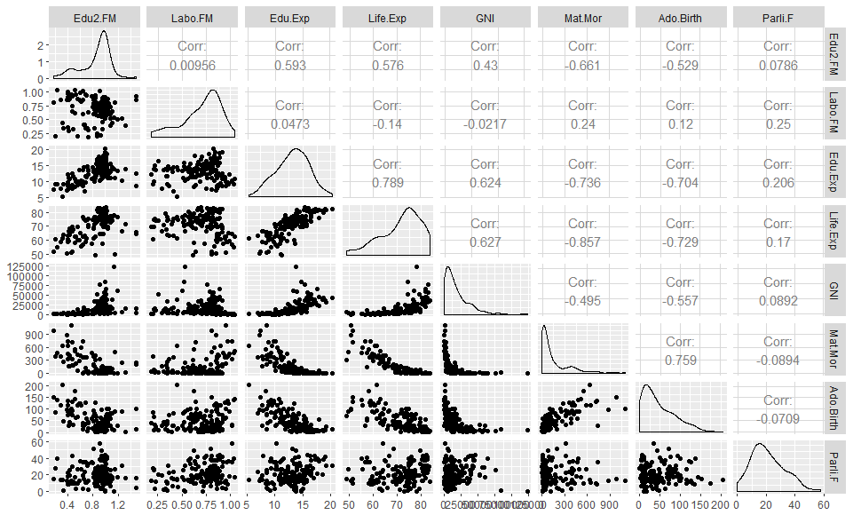

And next we can see a correlation plot

```
cor(human2) %>% corrplot(method="circle", type="upper")
```

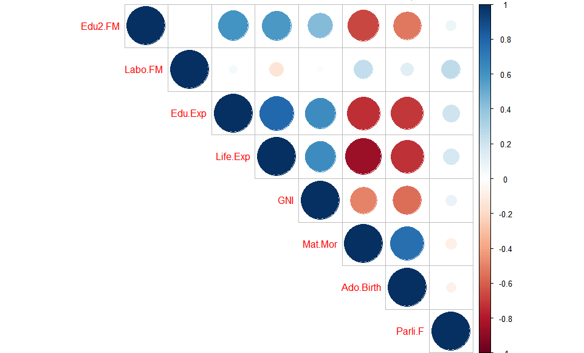

Correlation plot

We can make some observations based upon these two correlation plots. Correlation plot indicates with blue and red color plus the size of the circle. For example, there is a positive correlation between expected years of education and life expentancy. Maybe this could be interpreted in a way that suggests that when you spend more time getting educated - you will get safer job etc. Or maybe this just indicates the higher life expectancy in developed countries where people also enjoy more schooling than people in poorer countries obviously.

On the other hand there seems to be a strong negative correlation between life expectancy and maternal mortality. This is not that surprising considering that young people give birth and when they die they obviously won’t have a very long life expectancy. Also there is evidence for less education and maternal mortality.

From the variable summary we can see that the highest GNI 123 124 dollars and the lowest is 581 dollars. This really gives a perspective about income inequality in the world. Also there is countries which have no female represantation in parliament and the highest one is 57 %. The mean of that variable is also just 20.91 % which is very low.

### 3-5. Exercise

Well that was depressing, let’s turn the page and move on to the next exercise which is about principal component analysis(PCA). First we do this without the standardization and as we might expect the results will not be that good.

PCA helps us to find the principal components of the data. This makes it easier for us to handle the data because there are a lot less data to operate with.By using the biplot we visualize the connections between two representations of the same data. The scatter plot (grey) shows us two principal component which represent the observations. The pink arrows then visualize the connection with the original variables and the principal components. The arrows are closer to each other when they correlate for example Ado.birth and Mat.Mor. As you can see the x-axis represents the PC1 and all the variables which are on the “middle” for example Ado.Birth correlate with it. The variables which are towars the y-axis (Labo and Parli) correlate with PC2.

on the left side of the biplot there are richer countries and vice versa.

```
whuman2 <- prcomp(human2)

biplot(whuman2, choices = 1:2, cex = c(0.8, 1), col = c("grey40", "deeppink2"))
```

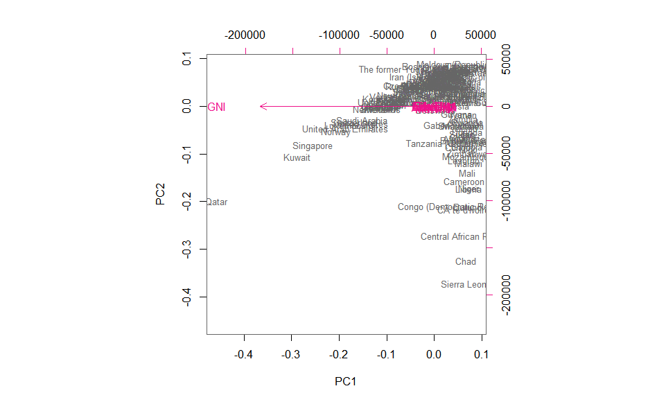

without the standardization

```
> summary(whuman2)
Importance of components:
                             PC1      PC2   PC3   PC4   PC5   PC6    PC7    PC8
Standard deviation     1.854e+04 185.5219 25.19 11.45 3.766 1.566 0.1912 0.1591
Proportion of Variance 9.999e-01   0.0001  0.00  0.00 0.000 0.000 0.0000 0.0000
Cumulative Proportion  9.999e-01   1.0000  1.00  1.00 1.000 1.000 1.0000 1.0000
```

As we can see without the standardization the biplot makes really no sense since they are not on the same scale. Let’s see what happens when we standardize the data first.

```
human2_std <-scale(human2)
human2_pca <- prcomp(human2_std)
summary(human2_pca)

Importance of components:
                          PC1    PC2     PC3     PC4     PC5     PC6     PC7     PC8
Standard deviation     2.0708 1.1397 0.87505 0.77886 0.66196 0.53631 0.45900 0.32224
Proportion of Variance 0.5361 0.1624 0.09571 0.07583 0.05477 0.03595 0.02634 0.01298
Cumulative Proportion  0.5361 0.6984 0.79413 0.86996 0.92473 0.96069 0.98702 1.00000
```

The summary of the data makes a lot more sense now, and we can also draw the biplot with the scaled data.

```
biplot(human2_pca, choices = 1:2, cex = c(0.8, 1), col = c("grey40", "deeppink2"))
```

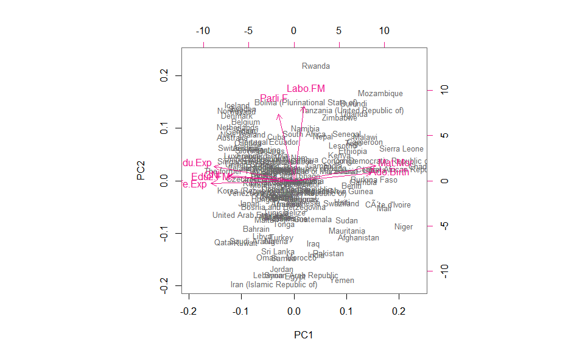

Labour force participation (Men and female) correlate with the number of women on the parliament. When women can work as a equal to men they can also participate more on the politics. Also on the right side we can see the negative values which do not correlate with thing like GNI such as maternal mortality rate and being pregnant young (15-19 year). PC2 can be thought as a indicator of gender equality. The higher on the Y-scale the better the equality between genders.

On personal note these all make very much sense, if you look at the countries on the plot the “best” countries for women and wealth are the nordics. If you go on the other direction you see countries some of which are on a war or poor.

# Tea dataset

First we download the new package called factominer and then we focus on one of its datas called tea. The tea dataframe has 300 observations and 36 variables.

```
> dim(tea)
[1] 300  36
> str(tea)
'data.frame':   300 obs. of  36 variables:
 $ breakfast       : Factor w/ 2 levels "breakfast","Not.breakfast": 1 1 2 2 1 2 1 2 1 1 ...
 $ tea.time        : Factor w/ 2 levels "Not.tea time",..: 1 1 2 1 1 1 2 2 2 1 ...
 $ evening         : Factor w/ 2 levels "evening","Not.evening": 2 2 1 2 1 2 2 1 2 1 ...
 $ lunch           : Factor w/ 2 levels "lunch","Not.lunch": 2 2 2 2 2 2 2 2 2 2 ...
 $ dinner          : Factor w/ 2 levels "dinner","Not.dinner": 2 2 1 1 2 1 2 2 2 2 ...
 $ always          : Factor w/ 2 levels "always","Not.always": 2 2 2 2 1 2 2 2 2 2 ...
 $ home            : Factor w/ 2 levels "home","Not.home": 1 1 1 1 1 1 1 1 1 1 ...
 $ work            : Factor w/ 2 levels "Not.work","work": 1 1 2 1 1 1 1 1 1 1 ...
 $ tearoom         : Factor w/ 2 levels "Not.tearoom",..: 1 1 1 1 1 1 1 1 1 2 ...
 $ friends         : Factor w/ 2 levels "friends","Not.friends": 2 2 1 2 2 2 1 2 2 2 ...
 $ resto           : Factor w/ 2 levels "Not.resto","resto": 1 1 2 1 1 1 1 1 1 1 ...
```

[output cut: 25 more lines]

Then we shall draw some ggplots with these variables. I thought that 36 variables would be nice to show on 3 pictures since it makes it easier to read.

```
gather(tea[1:12]) %>% ggplot(aes(value)) + geom_bar(fill="#FF9999", colour="black")+ theme(axis.text.x = element_text(angle = 45, hjust = 1, size = 8)) + facet_wrap("key", scales = "free")

gather(tea[13:24]) %>% ggplot(aes(value)) + geom_bar(fill="#FF9999", colour="black")+ theme(axis.text.x = element_text(angle = 45, hjust = 1, size = 8)) + facet_wrap("key", scales = "free")

gather(tea[25:36]) %>% ggplot(aes(value)) + geom_bar(fill="#FF9999", colour="black")+ theme(axis.text.x = element_text(angle = 45, hjust = 1, size = 8)) + facet_wrap("key", scales = "free")
```

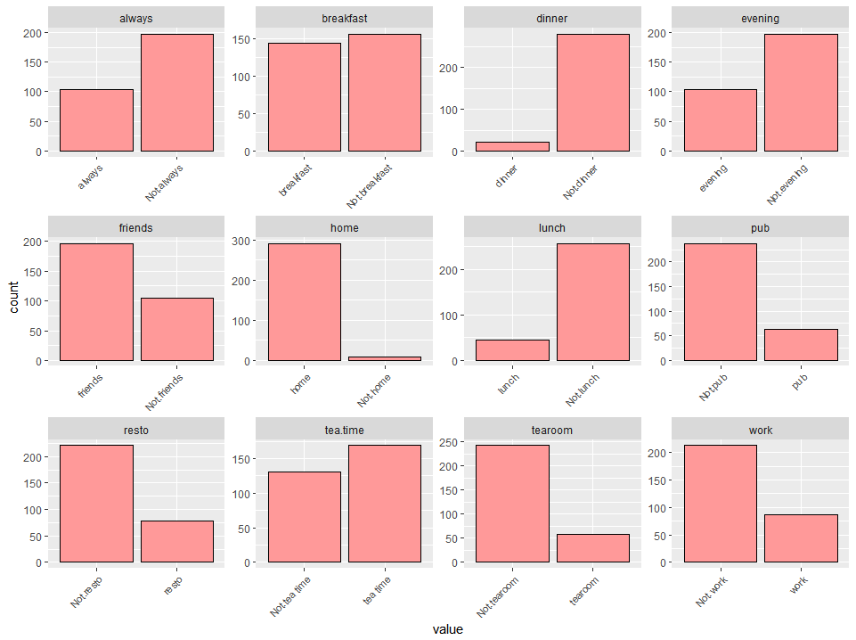

Variables from 1 to 12

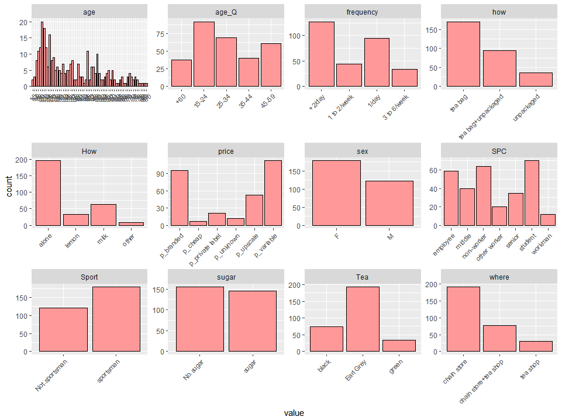

Variables from 13 to 24

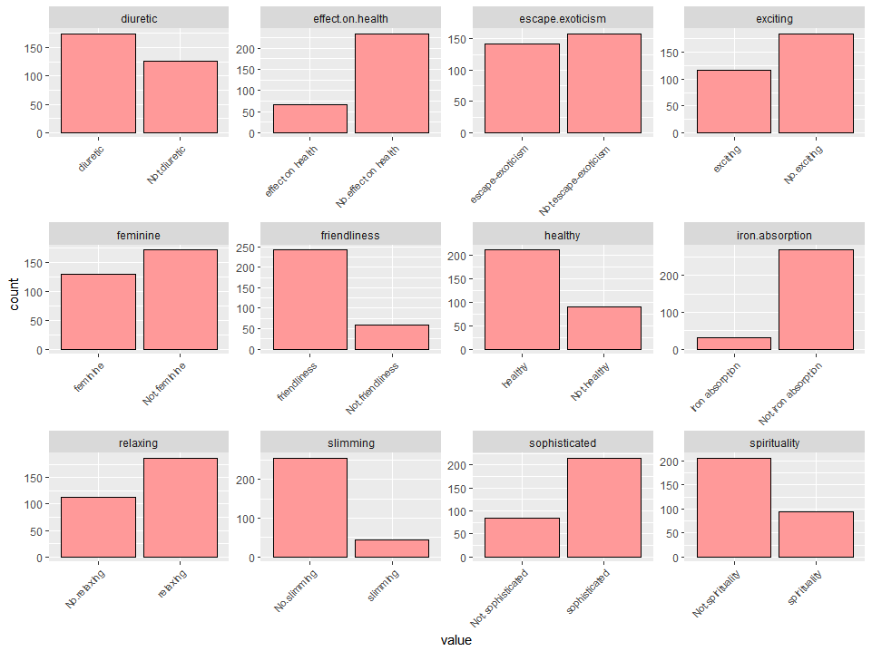

Variables from 25 to 36

So for the final part I cut the data fame to 6 variables which makes it easier to handle the data.

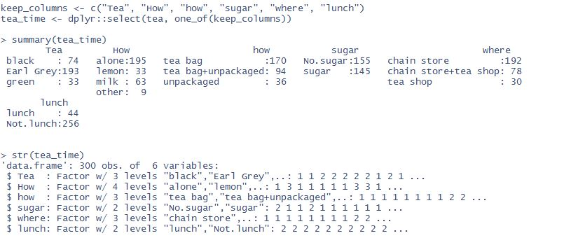

And let’s have a look also of the histogram of this data.

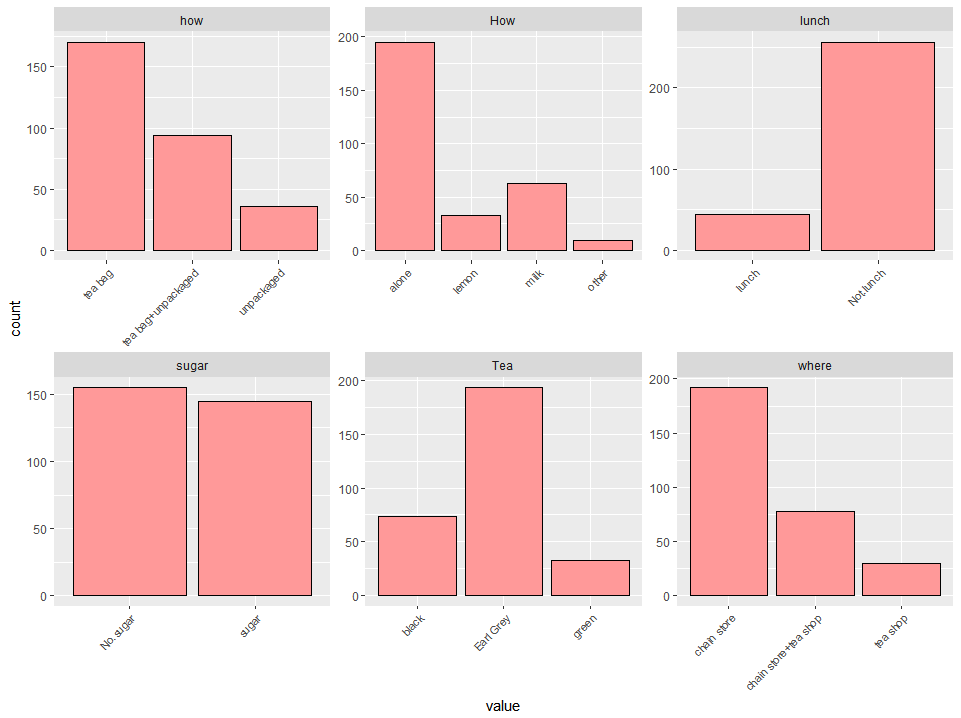

From the data we can see that most people make their tea with the teabag and they do not add anything extra to it. Earl grey is the typical type of tea and people usually drink their tea in a chain store rather than tea shop.

Then it’s time for the multiple correspondence analysis. It can be used for dimension reduction and to detect patterns or structure of the data. We hope to find some kind of evidence that these variables have something in common.

From the factor map below we can see that Dim1 contains more of a hipster perspective maybe since there is both unpackaged and tea shop favors. On the left on the x-axis there is maybe a bit more conservative taste like Earl grey and using teabags.

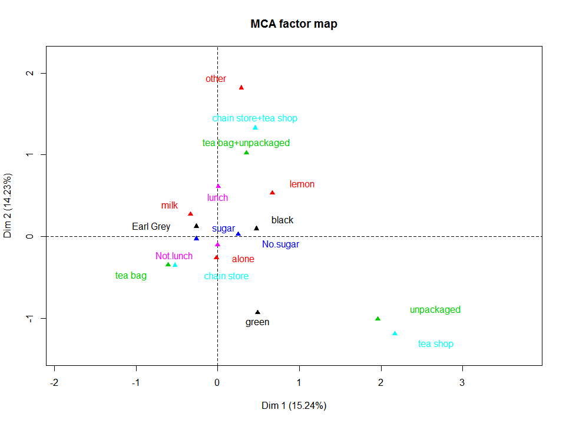

Let’s then move on to biplotting the data. I googled how to biplot mca in a good way and found “factoextra” package which I will use for the biplot.

```
install.packages("devtools")
library("devtools")
install_github("kassambara/factoextra")
library("factoextra")

fviz_mca_biplot(mca, axes = c(1, 2),  geom = c("point", "text", "arrow"))
```

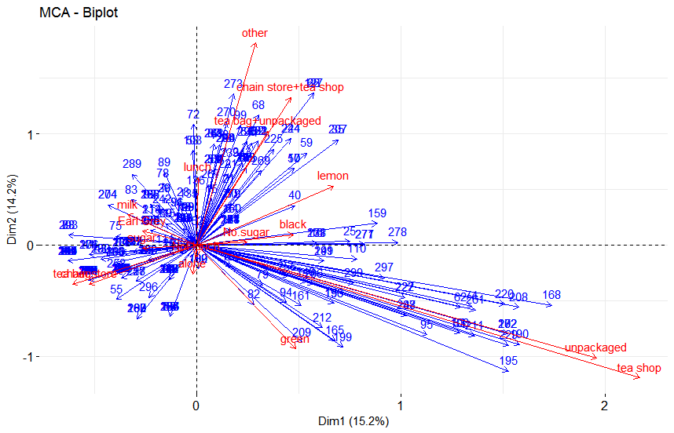

On this biplot the we can explore the correlations between variables(red) and the observations(blue) and the standard deviation.